# STAT 425 - HW7

Josh Janda

30 April, 2020

```r
library(splines)
library(tidyverse)
library(faraway)
library(leaps)
```

## Problem 1.

Use the prostate data with lpsa as the response and the other variables as predictors. Implement the following variable selection methods to determine the **best model**.

### A.

Backward elimination

```r
model = lm(lpsa ~ ., data = prostate)
```

```r
backward = step(model, direction = 'backward')
```

```
## Start:  AIC=-58.32
## lpsa ~ lcavol + lweight + age + lbph + svi + lcp + gleason +
##     pgg45
##
##           Df Sum of Sq    RSS     AIC
## - gleason  1    0.0412 44.204 -60.231
## - pgg45    1    0.5258 44.689 -59.174
## - lcp      1    0.6740 44.837 -58.853
## <none>                 44.163 -58.322
## - age      1    1.5503 45.713 -56.975
## - lbph     1    1.6835 45.847 -56.693
## - lweight  1    3.5861 47.749 -52.749
## - svi      1    4.9355 49.099 -50.046
## - lcavol   1   22.3721 66.535 -20.567
##
## Step:  AIC=-60.23
## lpsa ~ lcavol + lweight + age + lbph + svi + lcp + pgg45
##
##           Df Sum of Sq    RSS     AIC
## - lcp      1    0.6623 44.867 -60.789
## <none>                 44.204 -60.231
## - pgg45    1    1.1920 45.396 -59.650
## - age      1    1.5166 45.721 -58.959
## - lbph     1    1.7053 45.910 -58.560
## - lweight  1    3.5462 47.750 -54.746
## - svi      1    4.8984 49.103 -52.037
## - lcavol   1   23.5039 67.708 -20.872
##
## Step:  AIC=-60.79
## lpsa ~ lcavol + lweight + age + lbph + svi + pgg45
##
##           Df Sum of Sq    RSS     AIC
## - pgg45    1    0.6590 45.526 -61.374
## <none>                 44.867 -60.789
## - age      1    1.2649 46.131 -60.092
## - lbph     1    1.6465 46.513 -59.293
## - lweight  1    3.5647 48.431 -55.373
## - svi      1    4.2503 49.117 -54.009
## - lcavol   1   25.4189 70.285 -19.248
##
## Step:  AIC=-61.37
## lpsa ~ lcavol + lweight + age + lbph + svi
##
##           Df Sum of Sq    RSS     AIC
## <none>                 45.526 -61.374
## - age      1    0.9592 46.485 -61.352
## - lbph     1    1.8568 47.382 -59.497
## - lweight  1    3.2251 48.751 -56.735
## - svi      1    5.9517 51.477 -51.456
## - lcavol   1   28.7665 74.292 -15.871
```

With backwards selection, the best model after removal of some variables is the model with `age`, `lbph`, `lweight`, `svi`, and `lcavol`.

### B.

AIC and BIC

```r
model2 = regsubsets(lpsa ~ ., data = prostate)
summary_mod2 = summary(model2)
summary_mod2$which
```

```
##   (Intercept) lcavol lweight   age  lbph   svi   lcp gleason pgg45
## 1        TRUE   TRUE   FALSE FALSE FALSE FALSE FALSE   FALSE FALSE
## 2        TRUE   TRUE    TRUE FALSE FALSE FALSE FALSE   FALSE FALSE
## 3        TRUE   TRUE    TRUE FALSE FALSE  TRUE FALSE   FALSE FALSE
## 4        TRUE   TRUE    TRUE FALSE  TRUE  TRUE FALSE   FALSE FALSE
## 5        TRUE   TRUE    TRUE  TRUE  TRUE  TRUE FALSE   FALSE FALSE
## 6        TRUE   TRUE    TRUE  TRUE  TRUE  TRUE FALSE   FALSE  TRUE
## 7        TRUE   TRUE    TRUE  TRUE  TRUE  TRUE  TRUE   FALSE  TRUE
## 8        TRUE   TRUE    TRUE  TRUE  TRUE  TRUE  TRUE    TRUE  TRUE
```

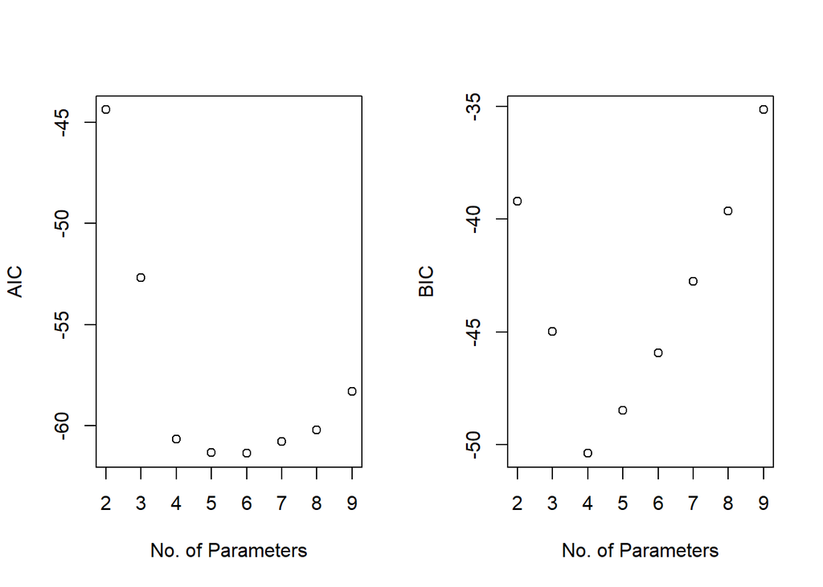

```r
n = nrow(prostate)
psize = 2:9
Aic = n*log(summary_mod2$rss/n) + 2*psize
Bic = n*log(summary_mod2$rss/n) + psize*log(n)

par(mfrow=c(1, 2))
plot(psize, Aic, xlab="No. of Parameters", ylab = "AIC");
plot(psize, Bic, xlab="No. of Parameters", ylab = "BIC");
```

Looking at the plots above, it seems that AIC selects the model with 6 parameters while BIC selects the model with 4 parameters.

```r
summary_mod2$which[which.min(Aic),]
```

```
## (Intercept)      lcavol     lweight         age        lbph         svi
##        TRUE        TRUE        TRUE        TRUE        TRUE        TRUE
##         lcp     gleason       pgg45
##       FALSE       FALSE       FALSE
```

```r
summary_mod2$which[which.min(Bic),]
```

```
## (Intercept)      lcavol     lweight         age        lbph         svi
##        TRUE        TRUE        TRUE       FALSE       FALSE        TRUE
##         lcp     gleason       pgg45
##       FALSE       FALSE       FALSE
```

So, when using AIC we select a model with more parameters which is expected due to its lesser penalty on the number of predictors included. For AIC, I choose a model with variables `lcavol`, `lweight`, `age`, `lbph`, `svi`, and the included intercept. For BIC, I select a model with `lcavol`, `lweight`, `svi`, and the included intercept. I select the same model using AIC as variable selection compared to backwards elimination, which makes sense as backwards elimination chooses the model with the lowest AIC.

### C.

Adjusted R^2

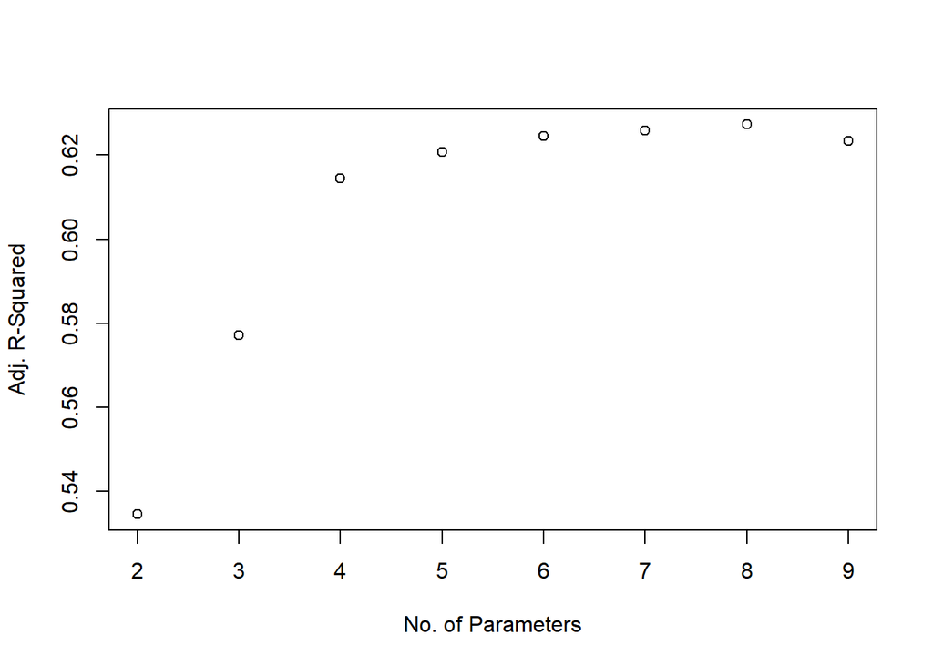

```r
plot(psize, summary_mod2$adjr2, xlab="No. of Parameters", ylab = "Adj. R-Squared")
```

The higher the $Adj. R^2$ the better. Comparing $Adj. R^2$ to AIC/BIC, $Adj. R^2$ penalizes the model for including more terms but at a much lesser penalty. This can be seen through this variable selection procedure as $Adj. R^2$ chooses a model with 8 parameters versus 6 parameters for AIC and 4 parameters for BIC.

```r
summary_mod2$which[which.max(summary_mod2$adjr2),]
```

```
## (Intercept)      lcavol     lweight         age        lbph         svi
##        TRUE        TRUE        TRUE        TRUE        TRUE        TRUE
##         lcp     gleason       pgg45
##        TRUE       FALSE        TRUE
```

### D.

Mallow’s Cp

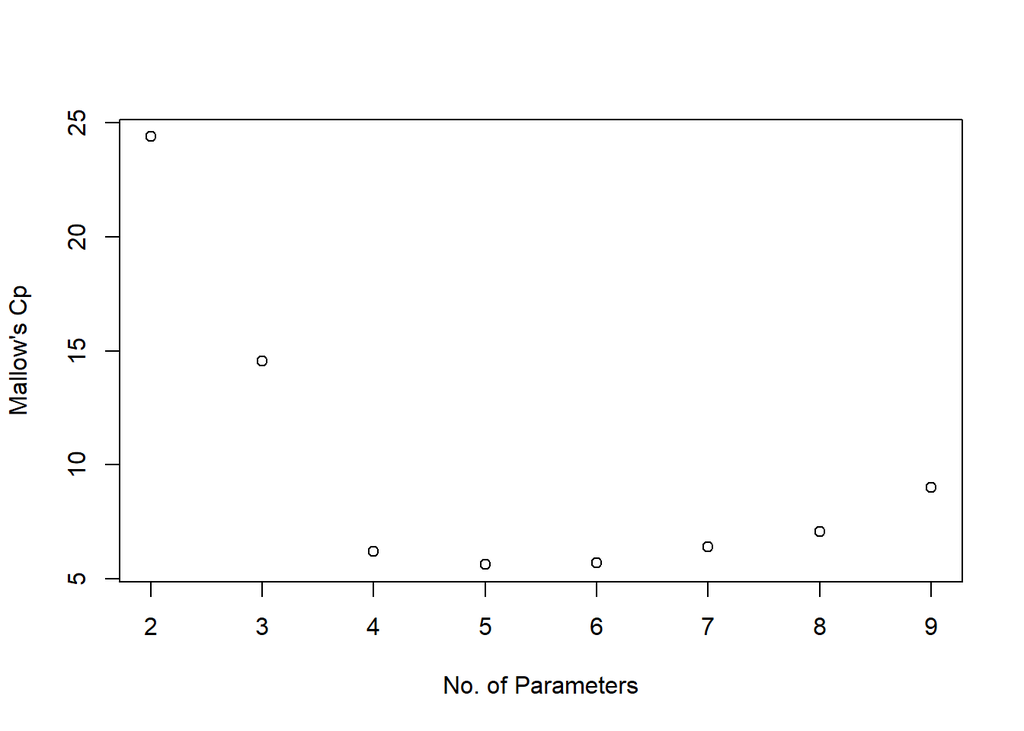

```r
plot(psize, summary_mod2$cp, xlab="No. of Parameters", ylab = "Mallow's Cp")
```

Mallow’s Cp is very similar to AIC. We want to choose a model that minimizes the Mallow’s Cp score. Looking at the plot above, this seems to be the model with 5 parameters.

```r
summary_mod2$which[which.min(summary_mod2$cp),]
```

```
## (Intercept)      lcavol     lweight         age        lbph         svi
##        TRUE        TRUE        TRUE       FALSE        TRUE        TRUE
##         lcp     gleason       pgg45
##       FALSE       FALSE       FALSE
```

This is a very similar model compared to the model selected with AIC, other than it does not include the `age` predictor.

Overall, through all of these variable selection procedures, I believe that the model chosen through BIC with four parameters is the best performing model due to the penalty term BIC holds. With this penalty term, we can assure to get a good model that is not overfit on too many parameters.

```r
best_mod = lm(lpsa ~ lcavol + lweight + svi, data = prostate)
summary(best_mod)
```

```
##
## Call:
## lm(formula = lpsa ~ lcavol + lweight + svi, data = prostate)
##
## Residuals:
##      Min       1Q   Median       3Q      Max
## -1.72964 -0.45764  0.02812  0.46403  1.57013
##
## Coefficients:
##             Estimate Std. Error t value Pr(>|t|)
## (Intercept) -0.26809    0.54350  -0.493  0.62298
## lcavol       0.55164    0.07467   7.388  6.3e-11 ***
## lweight      0.50854    0.15017   3.386  0.00104 **
## svi          0.66616    0.20978   3.176  0.00203 **
## ---
## Signif. codes:  0 '***' 0.001 '**' 0.01 '*' 0.05 '.' 0.1 ' ' 1
##
## Residual standard error: 0.7168 on 93 degrees of freedom
## Multiple R-squared:  0.6264, Adjusted R-squared:  0.6144
## F-statistic: 51.99 on 3 and 93 DF,  p-value: < 2.2e-16
```

All predictors are significant at $\alpha = .01$ and there is also a high $R^2$ and $Adj. R^2$.

```r
lpsa_sd = sd(prostate$lpsa)
sqrt(sum((best_mod$fitted.values - prostate$lpsa)^2))
```

```
## [1] 6.912659
```

## Problem 2.

Use simulated data from the model:

$$y = sin^3(2\pi x^3) + \epsilon$$
Where $\epsilon$ ~ $N(0, 0.1^2)$. Simulate at least 100 observations.

```r
set.seed(27)

x = seq(0,1, length.out = 10000)
epsilon = rnorm(10000, 0, 0.1)
y = sin(2*pi*x^3)^3 + epsilon

data = data.frame(x = x, y = y)
```

### A.

Fit a regression splines with 12 evenly-spaced knots using $y ∼ bs(x, 12)$. You need to load the splines package. Display the fit on the top of the simulated data.

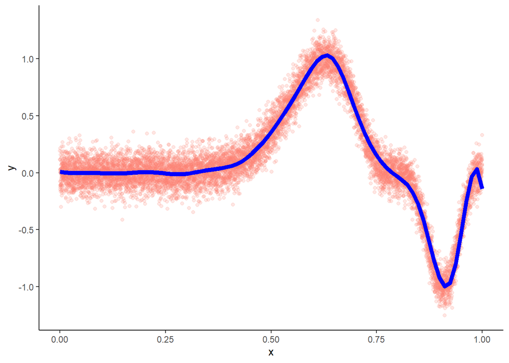

```r
spline_mod = lm(y ~ bs(x, df = 16), data = data)

ggplot(data = data, aes(x = x, y = y)) +
  geom_point(color = 'salmon', alpha = 0.2) +
  geom_smooth(method = 'lm', formula = y ~ bs(x, df = 16), se = FALSE,
              color = 'blue', size = 2) +
  theme(axis.line = element_line(color = 'black'),
        panel.background = element_blank())
```

### B.

Compute the BIC and AIC for this model.

```r
aic_and_bic = data.frame(AIC_Score = AIC(spline_mod),
                         BIC_Score = BIC(spline_mod))
aic_and_bic
```

```
##   AIC_Score BIC_Score
## 1 -16843.44 -16713.66
```

### C.

Compute the BIC and AIC for all models with a number of knots between 3 and 20 inclusive. Plot the BIC and AIC as a function of the number of parameters. Which model is the best?

```r
scores = data.frame(knots = 3:20,
                    AIC_scores = rep(0, 18),
                    BIC_scores = rep(0, 18)
                    )
i = 1
for (k in 3:20) {

  model = lm(y ~ bs(x, df = k + 4), data = data)
  aic_score = AIC(model)
  bic_score = BIC(model)
  scores$AIC_scores[i] = aic_score
  scores$BIC_scores[i] = bic_score
  i = i + 1

}
```

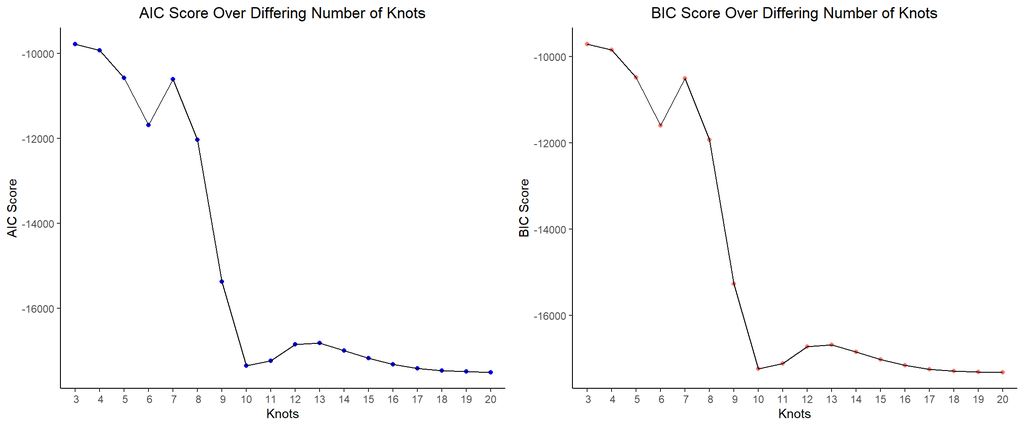

```r
ggplot(data = scores, aes(x = knots, y = AIC_scores)) +
  geom_point(color = 'blue') +
  geom_line(color = 'black') +
  labs(x = 'Knots', y = 'AIC Score', title = 'AIC Score Over Differing Number of Knots') +
  scale_x_discrete(limits = c(3:20)) +
  theme(plot.title = element_text(hjust = 0.5),
        panel.background = element_blank(),
        axis.line = element_line(color = 'black')) -> aic_plot
ggplot(data = scores, aes(x = knots, y = BIC_scores)) +
  geom_point(color = 'salmon') +
  geom_line(color = 'black') +
  labs(x = 'Knots', y = 'BIC Score', title = 'BIC Score Over Differing Number of Knots') +
  scale_x_discrete(limits = c(3:20)) +
  theme(plot.title = element_text(hjust = 0.5),
        panel.background = element_blank(),
        axis.line = element_line(color = 'black')) -> bic_plot
gridExtra::grid.arrange(aic_plot, bic_plot, nrow = 1)
```

The lower the AIC/BIC score the better. I can tell from these plots that the best model is with 20 knots as 20 knots corresponds to the lowest AIC and BIC scores.

```r
scores %>%
  filter(AIC_scores == min(AIC_scores),
         BIC_scores == min(BIC_scores)) %>%
  knitr::kable()
```

| knots | AIC_scores | BIC_scores |
| --- | --- | --- |
| 20 | -17497.28 | -17309.81 |

### D.

Plot the fit of your selected model on the top of the simulated data.

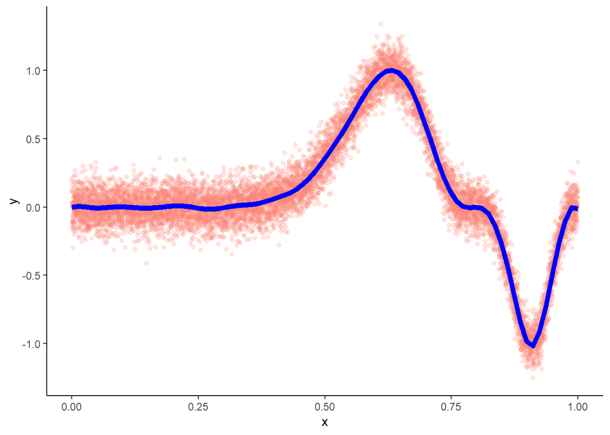

```r
ggplot(data = data, aes(x = x, y = y)) +
  geom_point(color = 'salmon', alpha = 0.2) +
  geom_smooth(method = 'lm', formula = y ~ bs(x, df = 24), se = FALSE,
              color = 'blue', size = 2) +
  theme(axis.line = element_line(color = 'black'),
        panel.background = element_blank())
```

Looking at the plot above, the fit is just a small amount better than with 12 knots making this a better model.